# Practical Machine Learning Coursera (R8)

Serban Tanasa

June 21, 2015

## Coursera JHBSPH Practical Machine Learning Course

The purpose of the course project was to learn the basics of machine learning in R. In the context of this course this was accomplished throught the use of the `caret` wrapper package that allows coding simple calls to complex machine learning algorithms such as Naive Bayes and Random Forests.

Load the datasets and tables

```r
setwd("/Data/Coursera8")
library(data.table)
library(caret)
list.files()
```

```
##  [1] "answers"                 "Coursera_R8Project"
##  [3] "coursera8.html"          "coursera8.R"
##  [5] "Coursera8.Rproj"         "coursera8.spin.R"
##  [7] "coursera8.spin.Rmd"      "FinalProjectReport.html"
##  [9] "FinalProjectReport.Rmd"  "modelfitted.RData"
## [11] "pml-testing.csv"         "pml-training.csv"
## [13] "submission.png"
```

```r
mydat <- fread("pml-training.csv", na.strings=c("NA","", "#DIV/0!"))
mytestdat <- fread("pml-testing.csv", na.strings=c("NA","", "#DIV/0!"))
```

Create a muging function, this cleans up variables we don’t need, removes those that have too many NAs. Make sure the test and validation data have the same structure.

```r
mungit <- function(my_dat)
     {
     my_dat <- as.data.frame(my_dat)
     my_dat$num_window <- NULL
     my_dat$raw_timestamp_part_1 <- NULL
     my_dat$raw_timestamp_part_2 <- NULL
     nums <- sapply(my_dat, is.numeric)
     mydat2 <- cbind(my_dat[, nums], classe=my_dat$classe)
     filter2 <- colSums(!is.na(mydat2))>19000
     mydat3 <- mydat2[, filter2]
     return(mydat3)
     }

mydat3 <-  mungit(mydat)
mytestdat2 <- as.data.frame(mytestdat)[,names(mydat3)[-53]]
```

Create the testing data

```r
set.seed(1233242)
inTrain <- createDataPartition(mydat3$classe, p=0.25, list=FALSE)
train <- mydat3[inTrain,]
test <- mydat3[-inTrain,]
```

We generate the model using random forests on 25% of the sample data. Tried several other methods on 5% data samples, but random forest empirically blew the others out of the water and required little tweaking.

Overall it’s amazing how such a powerful method can be written in one line of code below: :-)

```r
if(!"modelfitted.RData" %in% list.files())
{
     modelFit <- train(classe~., data=train, method="rf",
               preProcess="BoxCox")
     save(modelFit, file="modelfitted.RData")
} else load("modelfitted.RData")
```

Let’s take a look at the training results

```r
modelFit$modelInfo$tags
```

```
## [1] "Random Forest"              "Ensemble Model"
## [3] "Bagging"                    "Implicit Feature Selection"
```

```r
modelFit$results
```

```
##   mtry  Accuracy     Kappa  AccuracySD     KappaSD
## 1    2 0.9633685 0.9536001 0.004507010 0.005684964
## 2   27 0.9637112 0.9540420 0.005656423 0.007141441
## 3   52 0.9490910 0.9355186 0.008881819 0.011235368
```

```r
modelFit$finalModel$confusion
```

```
##      A   B   C   D   E class.error
## A 1386   6   2   1   0 0.006451613
## B   20 908  19   3   0 0.044210526
## C    0  18 831   6   1 0.029205607
## D    1   0  19 780   4 0.029850746
## E    1   4   5   5 887 0.016629712
```

Good Kappa and Mcnemar’s P, Overall accuracy 97.8%. Could be tweaked further, especially for classed B and D, with further tweaking of selected var, cleaner data using preProcess to center and normalize (BoxCox) … but since neither you (the reader) nor I the writer are getting paid for this, I suggest we stop here. The results can be deemed acceptable, let’s move on the the validation dataset:

```r
predictions <- predict(modelFit, newdata=test)
confusionMatrix(predictions, test$classe)
```

```
## Confusion Matrix and Statistics
##
##           Reference
## Prediction    A    B    C    D    E
##          A 4152   60    0    1    0
##          B   13 2739   37    4   10
##          C   14   48 2515   66   11
##          D    1    0   14 2334   32
##          E    5    0    0    7 2652
##
## Overall Statistics
##
##                Accuracy : 0.978
##                  95% CI : (0.9756, 0.9804)
##     No Information Rate : 0.2844
##     P-Value [Acc > NIR] : < 2.2e-16
##
##                   Kappa : 0.9722
##  Mcnemar's Test P-Value : < 2.2e-16
##
## Statistics by Class:
##
##                      Class: A Class: B Class: C Class: D Class: E
## Sensitivity            0.9921   0.9621   0.9801   0.9677   0.9804
## Specificity            0.9942   0.9946   0.9886   0.9962   0.9990
## Pos Pred Value         0.9855   0.9772   0.9476   0.9803   0.9955
## Neg Pred Value         0.9969   0.9909   0.9958   0.9937   0.9956
## Prevalence             0.2844   0.1935   0.1744   0.1639   0.1838
## Detection Rate         0.2822   0.1861   0.1709   0.1586   0.1802
## Detection Prevalence   0.2863   0.1905   0.1804   0.1618   0.1810
## Balanced Accuracy      0.9932   0.9783   0.9843   0.9819   0.9897
```

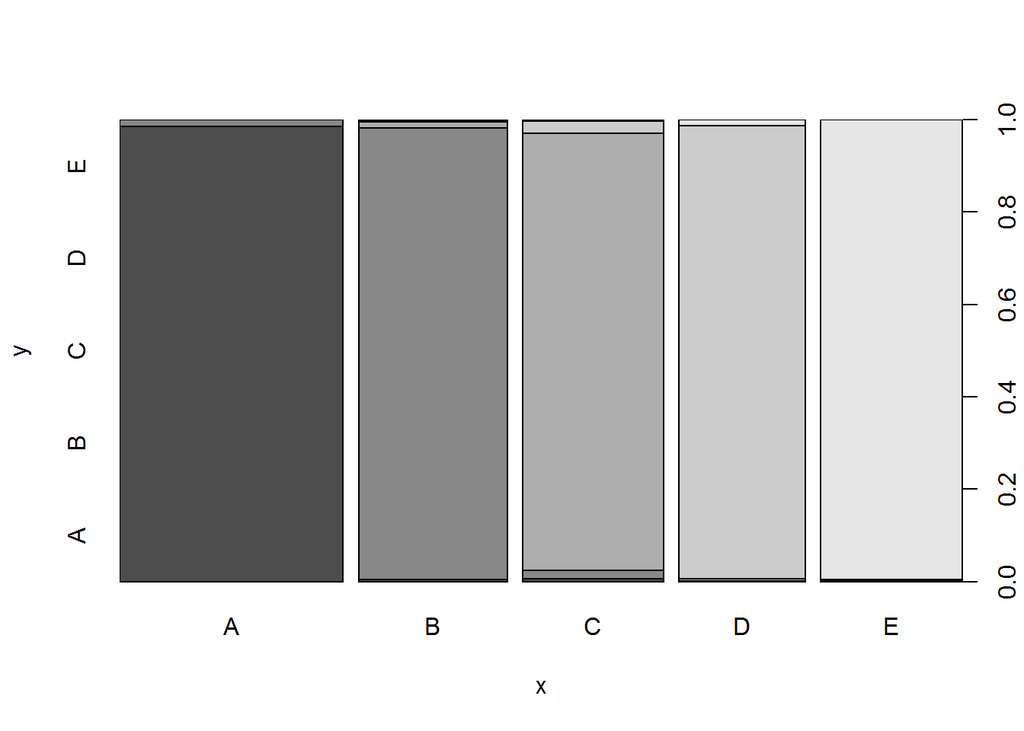

```r
plot(predictions, test$classe)
```

Acceptable results. Let’s move on to the test samples!

```r
pml_write_files = function(x){
     n = length(x)
     for(i in 1:n){
          filename = paste0("./answers/problem_id_",i,".txt")
          write.table(x[i],file=filename,quote=FALSE,
                      row.names=FALSE,col.names=FALSE)
     }
}


answers <- (predict(modelFit, newdata = mytestdat2))
if(length(list.files("./answers")<20)){
     pml_write_files(answers)
} else print("Results have been stored.")
```

Submission accuracy for the 20 test samples was 20/20, or 100%.